# Predictive Inference for Cognitive Decline Using Mixed Effects Models

2025-06-11

## Goals

- Predictive inference for cognitive decline in Alzheimer’s disease
- Explore the limitations of LMEs on non-normal response data

## Data Overview

- Subject ID
- Visit number
- Sex
- Age at visit
- Years of education
- Socioeconomic status (SES): score from 0-5
- Normalized whole brain volume (nWBV): ranges from 0-1
- Mini-Mental State Examination (MMSE): test score from 0-30
- Clinical Dementia Ratio (CDR): CDR = 0 (non-demented), CDR = 0.5 (very mild Alzheimer’s), CDR = 1 (mild Alzheimer’s)

```r
df <- read.csv(
  "D:/Daniel/Documents/MATH6642/final_project/Data/oasis_longitudinal.csv")
dc <- df[!is.na(df$MMSE) & !is.na(df$SES), ]

dc$SES <- 5 - dc$SES

dc_orig <- dc

dc <- dc[order(dc$Subject.ID, dc$Age), ]
```

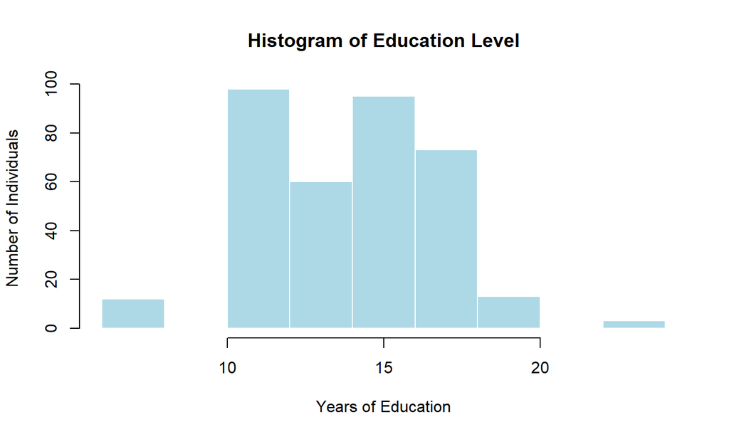

```r
hist(dc$EDUC,
     breaks = 10,
     main = "Histogram of Education Level",
     xlab = "Years of Education",
     ylab = "Number of Individuals",
     col = "lightblue",
     border = "white")
```

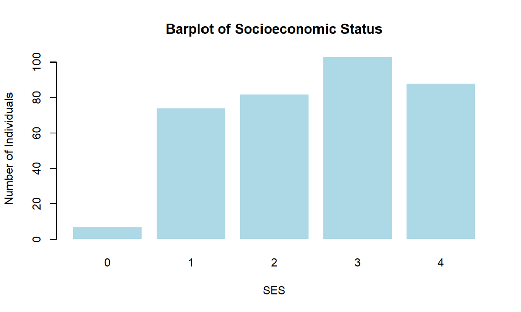

```r
barplot(table(dc$SES),
        main = "Barplot of Socioeconomic Status",
        xlab = "SES",
        ylab = "Number of Individuals",
        col = "lightblue",
        border = "white")
```

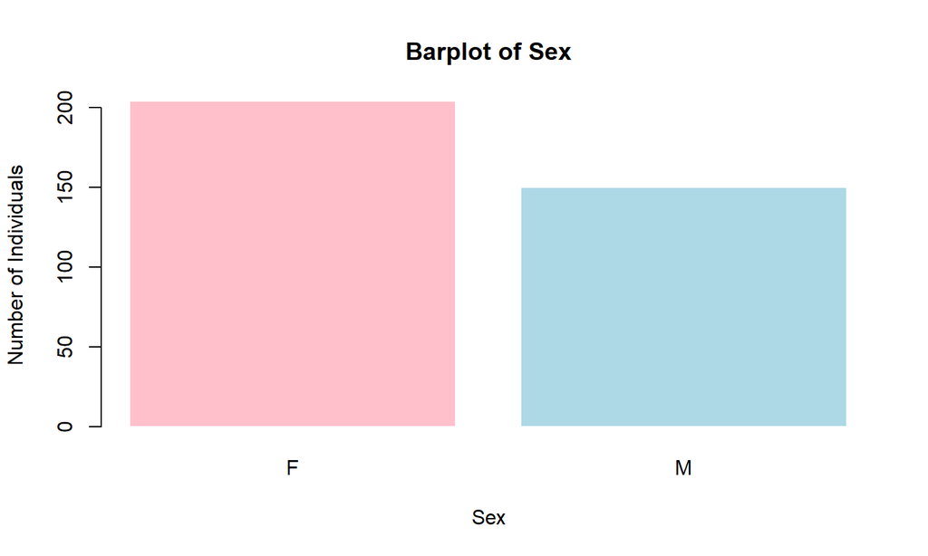

```r
barplot(table(dc$M.F),
        main = "Barplot of Sex",
        xlab = "Sex",
        ylab = "Number of Individuals",
        col = c("pink", "lightblue"),
        border = "white")
```

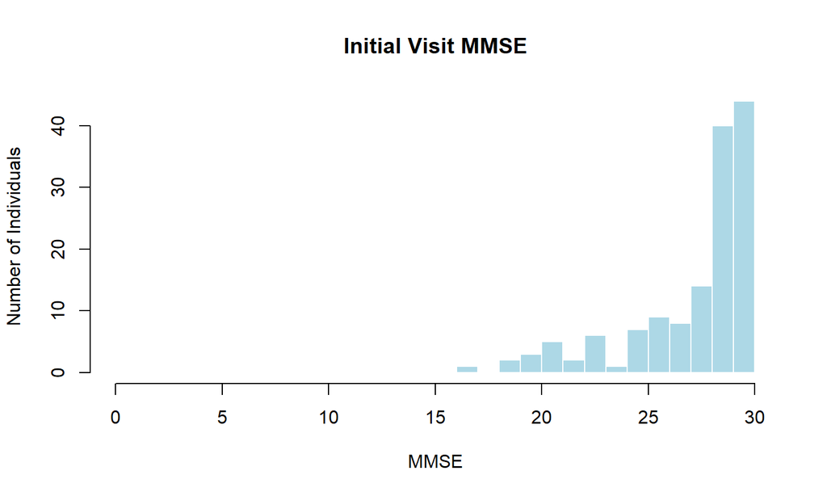

```r
initial_visits <- dc[ave(dc$Visit, dc$Subject.ID, FUN = min) == dc$Visit, ]
final_visits <- dc[ave(dc$Visit, dc$Subject.ID, FUN = max) == dc$Visit, ]

#Histogram for initial visits
hist(initial_visits$MMSE, main = "Initial Visit MMSE", breaks = 0:30, xlab = "MMSE",
     ylab = "Number of Individuals", col = "lightblue", border = "white", xlim = c(0, 30))
```

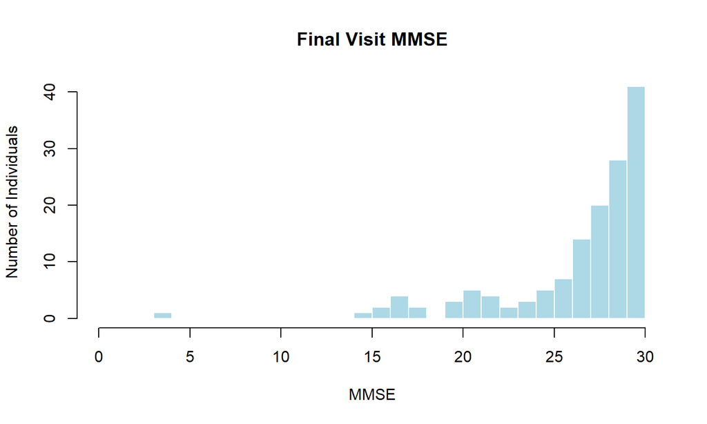

```r
#Histogram for final visits
hist(final_visits$MMSE, main = "Final Visit MMSE", breaks = 0:30, xlab = "MMSE",
     ylab = "Number of Individuals", col = "lightblue", border = "white", xlim = c(0, 30))
```

## Constructing the LME Model

Starting fixed effects:

- Age
- Years of education (EDUC)
- Socioeconomic status (SES)
- Brain volume (nWBV)
- Sex (M.F)

```r
fit1 <- lme(MMSE ~ nWBV + Age + M.F + SES + EDUC,
                  data = dc,
                  random = ~ 1 + Age | Subject.ID,
                  correlation = corAR1(form = ~ 1 | Subject.ID))
```

Random effects possibilities:

- random = ~ 1 | Subject.ID
- random = ~ 1 + Age | Subject.ID
- random = ~ 1 + nWBV

random = ~ 1 + nWBV has best AIC performance

```r
fit2 <- lme(MMSE ~ nWBV + Age + M.F + SES + EDUC,
            data = dc,
            random = ~ 1 + nWBV | Subject.ID,
            correlation = corAR1(form = ~ 1 | Subject.ID),
            control = lmeControl(opt = "optim", maxIter = 200,
            msMaxIter = 200))
```

```r
VarCorr(fit2)
```

```
## Subject.ID = pdLogChol(1 + nWBV)
##             Variance    StdDev    Corr
## (Intercept)  907.551971 30.125603 (Intr)
## nWBV        1463.567746 38.256604 -1
## Residual       3.542018  1.882025
```

```r
summary(fit2)$tTable
```

```
##                   Value  Std.Error  DF     t-value      p-value
## (Intercept)  0.29410337 7.15721747 210  0.04109186 9.672617e-01
## nWBV        29.82370524 7.11650373 210  4.19078053 4.094784e-05
## Age          0.04380276 0.03198838 210  1.36933323 1.723578e-01
## M.FM        -0.66622466 0.44214812 138 -1.50679068 1.341500e-01
## SES          0.09387467 0.26284222 138  0.35715216 7.215235e-01
## EDUC         0.13831876 0.10419206 138  1.32753641 1.865232e-01
```

For fixed effects:

Possible 3-way interactions:

- nWBV * Age * SES: SES influences access to healthcare, slowing decay in nWBV as the subject ages.
- nWBV * Age * M.F: Possible differences in nWBV decay by sex as the subject ages.
- nWBV * Age * EDUC: Higher education slows the loss of brain volume as the subject ages.

```r
fit3 <- lme(MMSE ~ nWBV + Age + M.F + SES + EDUC + nWBV * Age * SES
            + nWBV * Age + nWBV * SES + Age * SES,
            data = dc,
            random = ~ 1 + nWBV | Subject.ID,
            correlation = corAR1(form = ~ 1 | Subject.ID),
            control = lmeControl(opt = "optim", maxIter = 200,
                                 msMaxIter = 200))
```

```r
VarCorr(fit3)
```

```
## Subject.ID = pdLogChol(1 + nWBV)
##             Variance    StdDev    Corr
## (Intercept)  0.03821886 0.1954965 (Intr)
## nWBV         0.04110123 0.2027344 -0.371
## Residual    10.72286737 3.2745790
```

```r
summary(fit3)$tTable
```

```
##                     Value   Std.Error  DF    t-value   p-value
## (Intercept)  -109.6451897  93.3145687 206 -1.1750061 0.2413486
## nWBV          159.7594967 127.1639879 206  1.2563266 0.2104204
## Age             1.0239979   1.2219271 206  0.8380188 0.4029914
## M.FM           -0.5032879   0.5390608 138 -0.9336385 0.3521211
## SES            29.7143769  32.3897030 138  0.9174020 0.3605326
## EDUC            0.2038590   0.1294284 138  1.5750715 0.1175297
## nWBV:Age       -1.1008893   1.6808296 206 -0.6549678 0.5132191
## nWBV:SES      -36.1186355  44.4375366 206 -0.8127956 0.4172736
## Age:SES        -0.2651406   0.4224883 206 -0.6275692 0.5309812
## nWBV:Age:SES    0.3072175   0.5846036 206  0.5255143 0.5997909
```

Let’s consider 2-way interactions instead:

- nWBV * Age : Brain volume changes with age.
- nWBV * EDUC: Education acts as a buffer against brain volume loss.
- nWBV * SES : Higher SES allows for better healthcare, improving preservation of brain volume.
- nWBV * M.F : Sex affects brain volume.
- Age * EDUC : Education acts as a buffer against age effects.
- Age * M.F : Aging affects women and men differently.
- Age * SES : Higher SES acts as a buffer against age effects by again allowing for better healthcare.

```r
fit5 <- lme(MMSE ~ nWBV + Age + SES + nWBV * SES + Age * SES,
            data = dc,
            random = ~ 1 + nWBV | Subject.ID,
            correlation = corAR1(form = ~ 1 | Subject.ID),
            control = lmeControl(opt = "optim", maxIter = 200,
            msMaxIter = 200))
```

Lowest AIC so far, all terms statistically significant

```r
summary(fit5)$tTable
```

```
##                    Value   Std.Error  DF   t-value      p-value
## (Intercept) -54.94655627 16.87724929 208 -3.255658 1.320700e-03
## nWBV         85.06516352 16.96378182 208  5.014516 1.136780e-06
## Age           0.24594073  0.07957674 208  3.090611 2.270739e-03
## SES          21.81791319  6.12511634 140  3.562041 5.034821e-04
## nWBV:SES    -21.04512536  6.23253893 208 -3.376654 8.755957e-04
## Age:SES      -0.07694855  0.02853928 208 -2.696233 7.587196e-03
```

```r
VarCorr(fit5)
```

```
## Subject.ID = pdLogChol(1 + nWBV)
##             Variance    StdDev    Corr
## (Intercept) 1025.335434 32.020859 (Intr)
## nWBV        1677.873565 40.961855 -1
## Residual       3.402637  1.844624
```

## Diagnostics for G-Matrix

Try within-subject centering?

```r
test <- lme(MMSE ~ nWBV + Age + SES + nWBV * SES + Age * SES,
            data = dc,
            random = ~ 1 + dvar(nWBV, Subject.ID) | Subject.ID,
            correlation = corAR1(form = ~ 1 | Subject.ID),
            control = lmeControl(opt = "optim", maxIter = 200,
                                 msMaxIter = 200))

anova(fit5, test)
```

```
##      Model df      AIC      BIC    logLik
## fit5     1 11 1621.422 1663.796 -799.7112
## test     2 11 1643.240 1685.614 -810.6199
```

```r
VarCorr(test)
```

```
## Subject.ID = pdLogChol(1 + dvar(nWBV, Subject.ID))
##                        Variance    StdDev    Corr
## (Intercept)               7.461877  2.731644 (Intr)
## dvar(nWBV, Subject.ID) 6328.600137 79.552499 -0.733
## Residual                  2.333263  1.527502
```

```r
summary(test)$tTable
```

```
##                    Value   Std.Error  DF   t-value      p-value
## (Intercept) -50.99934937 16.98716373 208 -3.002229 3.008278e-03
## nWBV         79.97829545 17.19428944 208  4.651445 5.857928e-06
## Age           0.24054110  0.08325873 208  2.889080 4.272828e-03
## SES          16.51464807  6.21054872 140  2.659129 8.747329e-03
## nWBV:SES    -15.89944668  6.38933428 208 -2.488436 1.361561e-02
## Age:SES      -0.05631244  0.02943908 208 -1.912847 5.714120e-02
```

Trade-off:

Higher AIC, loss of interaction term in exchange for stable G-matrix

## Residuals

Reconstruct fit5 as a glmmTMB so we can use DHARMa to plot residuals:

```r
fit5_tmb <- glmmTMB(
  MMSE ~ nWBV + Age + SES + nWBV:SES + Age:SES + (1 + nWBV | Subject.ID),
  data = dc,
  REML = TRUE
)

res <- simulateResiduals(fittedModel = fit5_tmb)
```

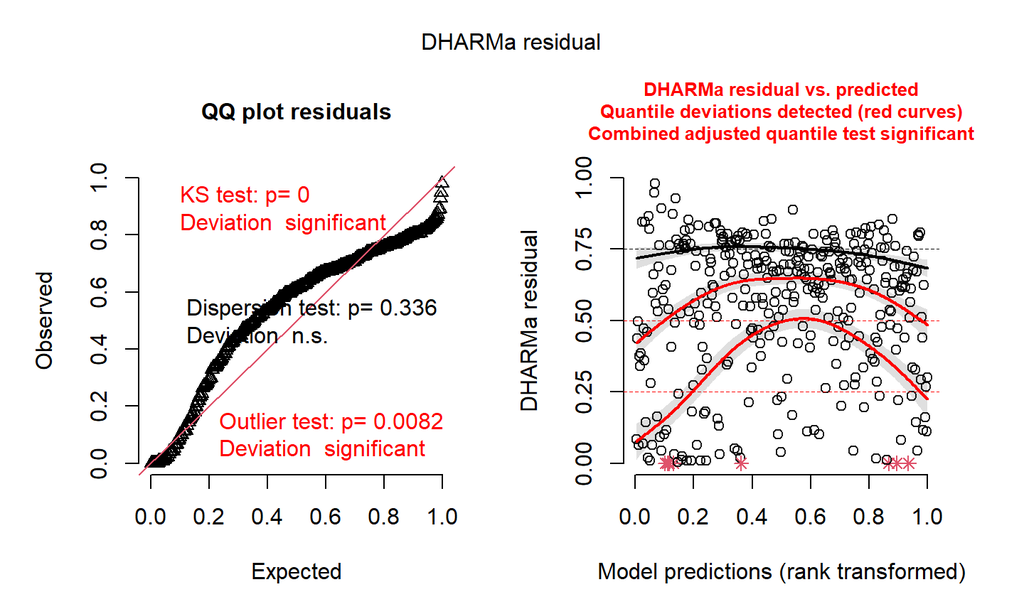

```r
plot(res)
```

Problems:

- Heteroskedasticity
- KS test: residuals are not uniformly distributed
- Outlier test: model handles outliers poorly

Let’s try non-linear terms.

```r
dc$nWBV_sq <- dc$nWBV^2

fit_nwbv_poly_raw <- glmmTMB(
  MMSE ~ nWBV + nWBV_sq + Age + SES + nWBV:SES + nWBV_sq:SES + Age:SES
  + (1 + nWBV | Subject.ID),
  data = dc,
  REML = TRUE
)

sim_nwbv_poly <- simulateResiduals(fit_nwbv_poly_raw)
```

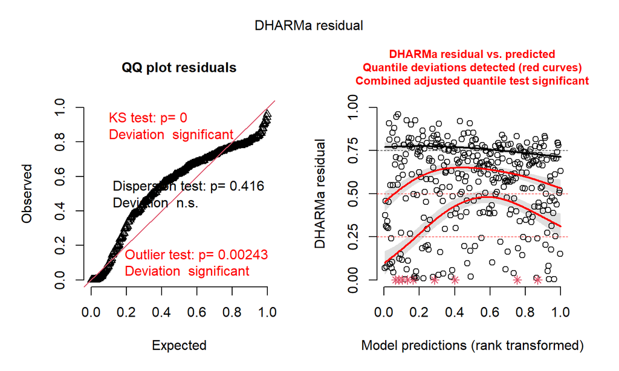

```r
plot(sim_nwbv_poly)
```

```r
AIC(fit_nwbv_poly_raw, fit5_tmb)
```

```
##                   df      AIC
## fit_nwbv_poly_raw 12 1601.715
## fit5_tmb          10 1628.256
```

```r
dc$nWBV_scaled <- scale(dc$nWBV)[,1]
dc$nWBV_sq_scaled <- dc$nWBV_scaled^2

fit6 <- lmer(MMSE ~ nWBV_scaled + nWBV_sq_scaled + Age + SES +
             nWBV_scaled * SES + Age * SES +
             (1 + nWBV_scaled | Subject.ID),
             data = dc)
```

```r
VarCorr(fit6)
```

```
##  Groups     Name        Std.Dev. Corr
##  Subject.ID (Intercept) 2.3125
##             nWBV_scaled 1.6125   -0.961
##  Residual               1.6309
```

```r
as.data.frame(summary(fit6)$coefficients[, "Pr(>|t|)"])
```

```
##                 summary(fit6)$coefficients[, "Pr(>|t|)"]
## (Intercept)                                 1.878264e-01
## nWBV_scaled                                 8.595034e-08
## nWBV_sq_scaled                              2.030934e-02
## Age                                         1.861178e-03
## SES                                         1.169573e-03
## nWBV_scaled:SES                             1.926432e-04
## Age:SES                                     2.587144e-03
```

What if we try splines?

```r
dc$ns_nWBV_scaled <- ns(dc$nWBV_scaled, df = 4)
ns_basis <- ns(dc$nWBV_scaled, df = 4)
ns_df <- as.data.frame(ns_basis)
colnames(ns_df) <- paste0("ns_nWBV_", 1:ncol(ns_df))

dc <- bind_cols(dc, ns_df)

fit_spline_tmb <- glmmTMB(
  MMSE ~ ns_nWBV_1 + ns_nWBV_2 + ns_nWBV_3 + Age + SES
  + nWBV * SES + Age * SES
  + (1 + nWBV | Subject.ID),
  data = dc,
  REML = TRUE
)

res_spline <- simulateResiduals(fit_spline_tmb)
```

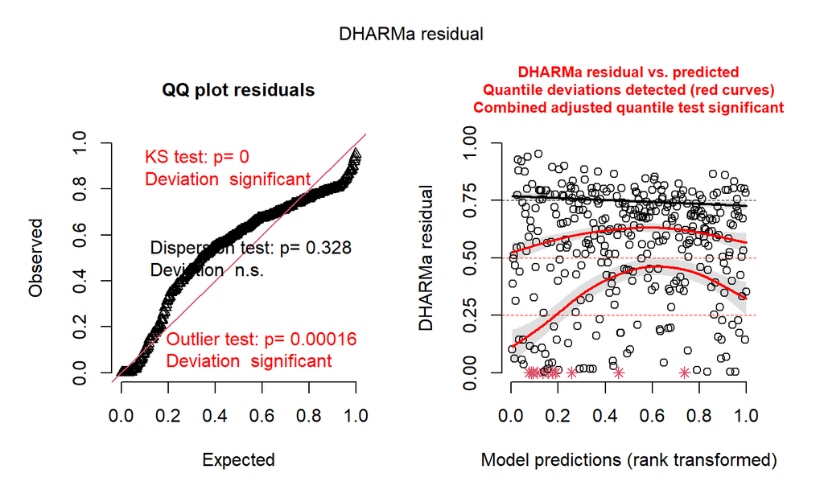

```r
plot(res_spline)
```

```r
dc$nWBV_scaled <- scale(dc$nWBV)[,1]

fit_spline <- lmer(MMSE ~ ns(nWBV_scaled, df=4) + Age + SES +
                     nWBV_scaled*SES + Age:SES +
                   (1 + nWBV_scaled | Subject.ID),
                   data = dc,
                   REML = TRUE)
```

```
## fixed-effect model matrix is rank deficient so dropping 1 column / coefficient
```

```r
VarCorr(fit_spline)
```

```
##  Groups     Name        Std.Dev. Corr
##  Subject.ID (Intercept) 2.3475
##             nWBV_scaled 1.6483   -0.953
##  Residual               1.5943
```

```r
as.data.frame(summary(fit_spline)$coefficients[, "Pr(>|t|)"])
```

```
##                          summary(fit_spline)$coefficients[, "Pr(>|t|)"]
## (Intercept)                                                3.886609e-01
## ns(nWBV_scaled, df = 4)1                                   1.144324e-09
## ns(nWBV_scaled, df = 4)2                                   1.452616e-08
## ns(nWBV_scaled, df = 4)3                                   1.443120e-09
## ns(nWBV_scaled, df = 4)4                                   3.127850e-07
## Age                                                        1.120163e-03
## SES                                                        9.066069e-04
## SES:nWBV_scaled                                            1.472280e-04
## Age:SES                                                    1.991614e-03
```

## Solution for Residuals?

Use a glmmTMB with zero-inflation.

```r
dc_c <- dc
dc_c$MMSE <- 30 - dc_c$MMSE
dc_c$nWBV_scaled <- scale(dc_c$nWBV)[,1]
dc_c$Age_scaled <- scale(dc_c$Age)[,1]
dc_c$SES_scaled <- scale(dc_c$SES)[,1]

fit5_tmb <- glmmTMB(
  MMSE ~ nWBV_scaled + Age_scaled + SES_scaled +
         nWBV_scaled * SES_scaled + Age_scaled * SES_scaled +
         (1 | Subject.ID),
  data = dc_c,
  ziformula = ~ Age_scaled,
  family = poisson,
  REML = TRUE
)
```

```r
AIC(fit5, fit5_tmb)
```

```
##          df      AIC
## fit5     11 1621.422
## fit5_tmb  9 1305.129
```

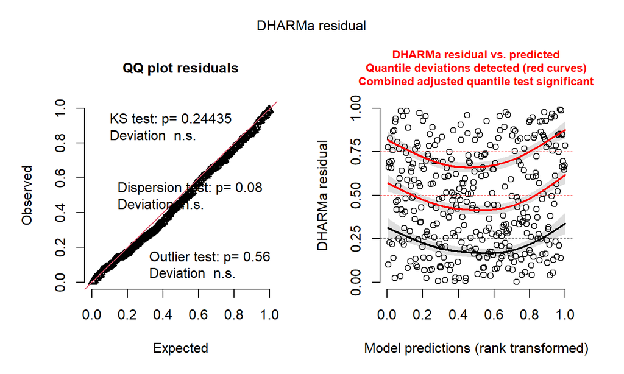

```r
res1 <- simulateResiduals(fit5_tmb)
plot(res1)
```

## Model Interpretation

```r
VarCorr(fit_spline)
```

```
##  Groups     Name        Std.Dev. Corr
##  Subject.ID (Intercept) 2.3475
##             nWBV_scaled 1.6483   -0.953
##  Residual               1.5943
```

```r
wald(fit_spline)
```

```
##  numDF denDF F-value p-value
##      9   Inf 2915.09 <.00001
##                          Estimate  Std.Error DF  t-value   p-value Lower 0.95
## (Intercept)              -6.066963 7.019796  Inf -0.864265 0.38744 -19.825510
## ns(nWBV_scaled, df = 4)1 12.596798 1.987106  Inf  6.339268 <.00001   8.702142
## ns(nWBV_scaled, df = 4)2 12.740600 2.124430  Inf  5.997184 <.00001   8.576793
## ns(nWBV_scaled, df = 4)3 28.718316 4.562693  Inf  6.294159 <.00001  19.775602
## ns(nWBV_scaled, df = 4)4 16.685178 3.085717  Inf  5.407228 <.00001  10.637283
## Age                       0.253806 0.076411  Inf  3.321600 0.00090   0.104044
## SES                       7.112171 2.100476  Inf  3.385980 0.00071   2.995314
## SES:nWBV_scaled          -0.904538 0.231527  Inf -3.906836 0.00009  -1.358323
## Age:SES                  -0.085723 0.027222  Inf -3.149001 0.00164  -0.139077
##                          Upper 0.95
## (Intercept)               7.691585
## ns(nWBV_scaled, df = 4)1 16.491454
## ns(nWBV_scaled, df = 4)2 16.904407
## ns(nWBV_scaled, df = 4)3 37.661031
## ns(nWBV_scaled, df = 4)4 22.733073
## Age                       0.403568
## SES                      11.229029
## SES:nWBV_scaled          -0.450754
## Age:SES                  -0.032368
```

## Model Comparison

```r
AIC(fit5, fit6, fit_spline)
```

```
##            df      AIC
## fit5       11 1621.422
## fit6       11 1639.894
## fit_spline 13 1624.226
```

```r
cdr_colors <- c("0" = "lightblue", "0.5" = "violet", "1" = "darkblue")

#nWBV trajectories
nWBV_traj <- xyplot(nWBV ~ Age, data = dc,
       groups = Subject.ID,
       type = "b",
       lwd = 1,
       pch = 16,
       col = cdr_colors[as.character(dc$CDR)],
       xlab = "Age (years)",
       ylab = "nWBV (%)",
       main = "Longitudinal trajectories of nWBV per subject by CDR group",
       key = list(text = list(c("CDR 0", "CDR 0.5", "CDR 1")),
                  points = list(pch = 16, col = c("lightblue", "violet", "darkblue")),
                  columns = 3))
```

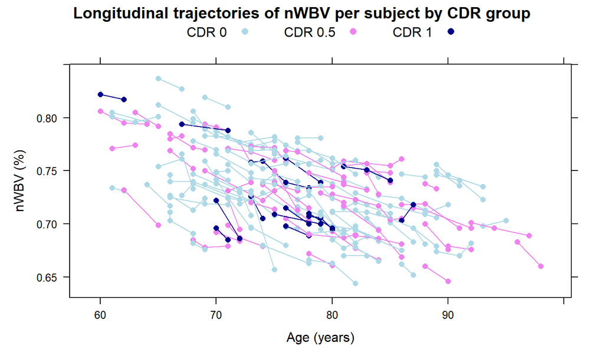

```r
nWBV_traj
```

```r
#MMSE trajectories
MMSE_traj <- xyplot(MMSE ~ Age, data = dc,
       groups = Subject.ID,
       type = "b",
       lwd = 1,
       pch = 16,
       col = cdr_colors[as.character(dc$CDR)],
       xlab = "Age (years)",
       ylab = "MMSE",
       main = "Longitudinal trajectories of MMSE per subject by CDR group",
       key = list(text = list(c("CDR 0", "CDR 0.5", "CDR 1")),
                  points = list(pch = 16, col = c("lightblue", "violet", "darkblue")),
                  columns = 3))
```

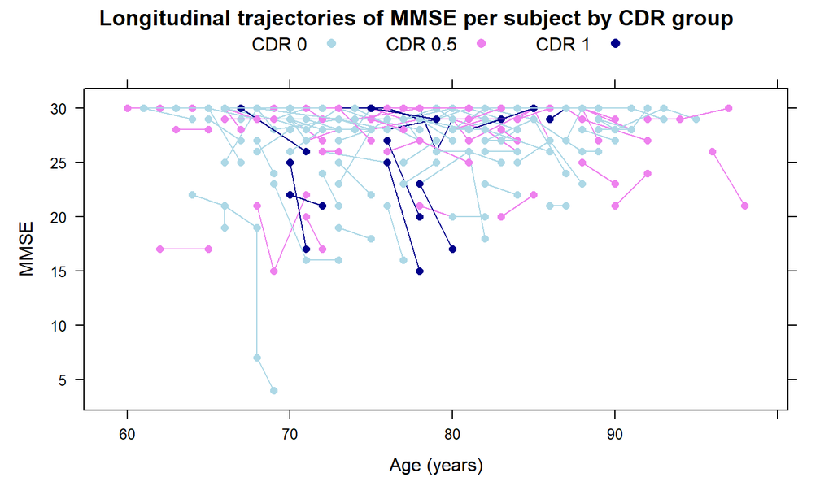

```r
MMSE_traj
```

```r
dc_copy <- dc

subject_slopes <- dc_copy %>%
  group_by(Subject.ID, CDR) %>%
  filter(n() > 1) %>%  # need at least two points per subject
  summarise(
    slope = {
      fit <- lm(MMSE ~ Age, data = cur_data())
      coef(fit)["Age"]
    },
    .groups = "drop"
  )
avg_slopes_by_CDR_old <- subject_slopes %>%
  group_by(CDR) %>%
  summarise(
    avg_slope = mean(slope, na.rm = TRUE),
    n = n()
  )
```

```r
dc$fit_vals5 <- fitted(fit5)

dc_slope <- dc %>%
  select(Subject.ID, Age, fit_vals5, CDR) %>%
  group_by(Subject.ID, CDR) %>%
  arrange(Age, .by_group = TRUE) %>%
  summarise(
    slope = if (n() >= 2) coef(lm(fit_vals5 ~ Age))[2] else NA_real_,
    .groups = "drop"
  )

avg_slopes_by_CDR_5 <- dc_slope %>%
  group_by(CDR) %>%
  summarise(
    avg_slope = mean(slope, na.rm = TRUE),
    n = n()
  )
```

```r
dc$fit_vals6 <- fitted(fit6)

dc_slope <- dc %>%
  select(Subject.ID, Age, fit_vals6, CDR) %>%
  group_by(Subject.ID, CDR) %>%
  arrange(Age, .by_group = TRUE) %>%
  summarise(
    slope = if (n() >= 2) coef(lm(fit_vals6 ~ Age))[2] else NA_real_,
    .groups = "drop"
  )

avg_slopes_by_CDR_6 <- dc_slope %>%
  group_by(CDR) %>%
  summarise(
    avg_slope = mean(slope, na.rm = TRUE),
    n = n()
  )
```

```r
dc$fit_spline <- fitted(fit_spline)

dc_slope <- dc %>%
  select(Subject.ID, Age, fit_spline, CDR) %>%
  group_by(Subject.ID, CDR) %>%
  arrange(Age, .by_group = TRUE) %>%
  summarise(
    slope = if (n() >= 2) coef(lm(fit_spline ~ Age))[2] else NA_real_,
    .groups = "drop"
  )

avg_slopes_by_CDR <- dc_slope %>%
  group_by(CDR) %>%
  summarise(
    avg_slope = mean(slope, na.rm = TRUE),
    n = n()
  )
```

```r
print(avg_slopes_by_CDR_old)
```

```
## # A tibble: 3 × 3
##     CDR avg_slope     n
##   <dbl>     <dbl> <int>
## 1   0     -0.0306    76
## 2   0.5   -0.464     38
## 3   1     -0.826      9
```

```r
print(avg_slopes_by_CDR_5)
```

```
## # A tibble: 4 × 3
##     CDR avg_slope     n
##   <dbl>     <dbl> <int>
## 1   0     0.00224    86
## 2   0.5  -0.160      61
## 3   1    -0.946      22
## 4   2   NaN           3
```

```r
print(avg_slopes_by_CDR_6)
```

```
## # A tibble: 4 × 3
##     CDR avg_slope     n
##   <dbl>     <dbl> <int>
## 1   0     -0.0135    86
## 2   0.5   -0.227     61
## 3   1     -1.20      22
## 4   2    NaN          3
```

```r
print(avg_slopes_by_CDR)
```

```
## # A tibble: 4 × 3
##     CDR avg_slope     n
##   <dbl>     <dbl> <int>
## 1   0     -0.0198    86
## 2   0.5   -0.302     61
## 3   1     -1.29      22
## 4   2    NaN          3
```

- Model with only linear terms is closest for CDR = 1
- Spline model is closest for CDR = 0, CDR = 0.5
- Incorporating non-linearity seems to steepen the mean decline for each CDR group

## References

- Marcus, Fotenos, et. al., (2010). *Open Access Series of Imaging Studies: Longitudinal MRI Data in Nondemented and Demented Older Adults*. MIT Press.
- Marcus, Wang, et al., (2007). *Open Access Series of Imaging Studies (OASIS): cross-sectional MRI data in young, middle aged, nondemented, and demented older adults*. MIT Press.
- Boysen, J., (2017). *MRI and Alzheimers*. Kaggle. Retrieved from https://www.kaggle.com/datasets/jboysen/mri-and-alzheimers
- Morris, J. C., (1993). *The Clinical Dementia Rating (CDR) : Current version and scoring rules*. Wolters Kluwer.
- Folstein, Folstein & McHugh, (1975). *“Mini-mental state”: A practical method for grading the cognitive state of patients for the clinician*. Elsevier.
- Rasmussen & Langerman, (2019). *Alzheimer’s Disease – Why We Need Early Diagnosis*. Dove Medical Press.

Thanks for your attention!